# Parcial 1: Biodisponibilidad y Bioequivalencia 2018-01

Parra G., Daniel S.

19 de septiembre de 2018

# 1. Introducción

Se ha efectuado un estudio para demostrar la bioequivalencia entre dos productos que llevan como principio activo Antibiótico SP-4X el que se prescribe a razón de 140 mg por vía IV y 700 mg por vía oral en presentación de tabletas. Para el estudio se utilizó un diseño experimental cruzado con 12 voluntarios, los que se dividieron en 2 grupos de 6 voluntarios, quienes recibieron en periodos diferentes los dos productos en estudio (referencia y competidor). El estudio estuvo completamente controlado los voluntarios fueron todos hombres con edades comprendidas entre los 20 y 35 años y con un peso promedio de 70 kilogramos, la alimentación fue estandarizada y el producto se administró en ayunas con 250 mL de agua, después de 10 horas de ayuno. Del análisis de las muestras de sangre, por un método bioanalítico validado, se obtuvieron los datos que se indican a continuación y se solicita calcular:

1. La constante de velocidad de eliminación ($k_{e}$) del antibiótico en la muestra poblacional utilizada, datos individuales y el promedio poblacional con su variabilidad (emplear la constante determinada por la vía IV en los cálculos subsiguientes de AUC$|_{0}^{\infty}$).
2. Determinar la constante de velocidad de absorción para el fármaco en los dos productos. Datos individuales y el promedio poblacional con su variabilidad (emplear la constante correspondiente a cada producto para los cálculos del $C_{max}$ y del $t_{max}$).
3. Calcule y tabule los parámetros biofarmacéuticos para cada producto en cada individuo y establezca el valor medio ($\bar{\theta}$) y su variabilidad, ilustre los resultados con las gráficas correspondientes para cada individuo con los dos productos (una sóla gráfica para los 12 individuos de un mismo producto). Establezca la gráfica promedio poblacional para cada producto (En esta se compara en una misma los dos productos).
4. ¿Cuál es la biodisponibilidad $F$ de cada producto?
5. Se podrían considerar bioequivalentes los dos productos, ¿por qué? Justifique plenamente su respuesta.

# 2. Etapa de Modelamiento

## 2.1. Modelamiento Individual Datos Administración IV

Se han modelado mediante regresión no-lineal los datos de concentración-tiempo para el producto de referencia tras admistración intravenosa (IV). El modelo farmacocinético para estos datos corresponde a modelo de 1 compartimento que se describe de manera general por ecuaciones diferenciales:

$$\left\{\begin{matrix} \frac{dx_{1}(t)}{dt} = k_{e}x_{1}(t)+k_{a}x_{2}(t)+r(t) \\ \frac{dx_{2}(t)}{dt} = -k_{a}x_{2}(t) \end{matrix}\right.$$
En una forma matricial es equivalente a la siguiente expresión:
$$\frac{\mathrm{d} \vec{x}}{\mathrm{d} t} = \frac{\mathrm{d} }{\mathrm{d} t} \begin{bmatrix} x_{1}(t)\\ x_{2}(t) \end{bmatrix} = \begin{bmatrix} -k_{e} & k_{a} \\ 0 & k_{a} \end{bmatrix} \cdot \begin{bmatrix}x_{1}(t)\\x_{2}(t)\end{bmatrix} + \begin{bmatrix}r(t)\\0\end{bmatrix}$$
En este caso $x_{1}$ y $x_{2}$ son las cantidades en los compartimentos 1 (central), y 2 (absorción) en unidades de masa. De esta se puede obtener la concentración plasmática $C_{P}$ al dividir la cantidad en el compartimento central $x_{1}$ sobre el volumen de distribución $V_{D}$. Las constantes de velocidad $k_{a}$ y $k_{e}$ son de absorción y eliminación respectivamente, el término $r(t)$ se añade para denotar un aporte de fármaco al sistema de primer órden (p. ej. en el caso de infusión continua).

En el caso de administración IV en forma de bolo simple, se puede resolver la ecuación de manera analítica relacionando $C_{p}$ y tiempo. Al tener en cuenta también el error residual, se tiene el siguiente modelo no lineal:

$$\vec{C_{p}} = \frac{D_{0}}{V_{D}}\cdot e^{-k_{e}\cdot \vec{t}} + \vec{\varepsilon} \qquad \vec{\varepsilon}\sim \mathcal{N}(0,\,\sigma^{2})$$

En este caso se tiene que $\vec{C_{p}}$ es el vector de concentraciones plasmáticas observadas, mientras $\vec{t}$ es un vector que corresponde a los tiempos en los cuales se han medido las concentraciones. Se tiene que $D_{0}$ es la dosis administrada en bolo, y $\vec{\varepsilon}$ es un vector con residuales que se definen como la diferencia entre las concentraciones plasmáticas observadas menos las predichas por el modelo. Los residuales se distribuyen de manera nomal alrededor de cero con varianza $\sigma^{2}$. El modelo está parametrizado con $k_{e}$ y $V_{D}$, y se pueden obtener parámetros secundarios como clearance total $CL_{T} = k_{e} \cdot V_{D}$, concentración inicial $C_{0} = \frac{D_{0}}{V_{D}}$, y tiempo de vida media $t_{1/2} = \ln{2}/k_{e}$.

El área bajo la curva truncada y total se obtienen al sumar las áreas por el método de trapezoides, que se define para un intervalo de tiempo entre el primer punto y el último punto de muestreo ($C_{p}^{*}$):
$$\textrm{AUC}_{\textrm{TRUNC}} = \left(\frac{(C_{0}+C_{p}(t_{1}))}{2} \cdot t_{1}\right ) + \sum_{i=1}^{n-1}{ \frac{(C_{p}(t_{i})+C_{p}(t_{i+1}))}{2} \cdot (t_{i+1}-t_{i})}$$

El área bajo la curva total se define por medio de la siguiente expresión:
$$\textrm{AUC} = \left(\frac{(C_{0}+C_{p}(t_{1}))}{2} \cdot t_{1}\right ) + \sum_{i=1}^{n-1}{ \frac{(C_{p}(t_{i})+C_{p}(t_{i+1}))}{2} \cdot (t_{i+1}-t_{i})} + \frac{C_{p}(t_{n}))}{k_{e}}$$
El modelamiento se ha realizado por medio del algoritmo de Gauss-Newton, la función objetivo tiene la forma de suma de errores al cuadrado $S(\theta) = \sum_{i=1}^{n}{\varepsilon_{i}^2}$, como no tiene una solución analítica se realiza un procedimiento de optimización. Las variables de optimización son 50 iteraciones máximo, criterio de tolerancia <1E-05, sin límites para los parámetros, y con valor de ascenso de 1/1024. En el cuadro 1, se puede observar un reporte de los resultados de modelamiento para los datos de administración intravenosa.

Resultados de Regresión Modelos 1 Compartimento (Producto IV)

| ID | Dosis | $V_{D}$ | $k_{e}$ | $CL_{T}$ | $C_{0}$ | $t_{1/2}$ | AUC$_{0}^{C_{P}^{*}}$ | AUC$_{0}^{\infty}$ |
| --- | --- | --- | --- | --- | --- | --- | --- | --- |
| Sujeto 01 | 140 | 21.005 | 0.230 | 4.828 | 6.665 | 3.015 | 27.374 | 29.201 |
| Sujeto 02 | 140 | 20.385 | 0.230 | 4.688 | 6.868 | 3.013 | 28.192 | 30.062 |
| Sujeto 03 | 140 | 21.663 | 0.230 | 4.976 | 6.463 | 3.017 | 26.556 | 28.341 |
| Sujeto 04 | 140 | 19.995 | 0.230 | 4.602 | 7.002 | 3.011 | 28.720 | 30.632 |
| Sujeto 05 | 140 | 22.122 | 0.230 | 5.077 | 6.329 | 3.019 | 26.027 | 27.770 |
| Sujeto 06 | 140 | 21.879 | 0.230 | 5.032 | 6.399 | 3.013 | 26.265 | 28.004 |
| Sujeto 07 | 140 | 20.198 | 0.230 | 4.640 | 6.931 | 3.017 | 28.483 | 30.398 |
| Sujeto 08 | 140 | 19.449 | 0.230 | 4.474 | 7.198 | 3.013 | 29.532 | 31.488 |
| Sujeto 09 | 140 | 22.845 | 0.230 | 5.246 | 6.128 | 3.018 | 25.190 | 26.888 |
| Sujeto 10 | 140 | 20.388 | 0.234 | 4.778 | 6.867 | 2.957 | 27.702 | 29.537 |
| Sujeto 11 | 140 | 22.129 | 0.231 | 5.104 | 6.327 | 3.005 | 25.949 | 27.727 |
| Sujeto 12 | 140 | 21.917 | 0.232 | 5.083 | 6.388 | 2.988 | 26.027 | 27.665 |

En la figura 1 se pueden observar los perfiles farmacocinéticos (concentración-tiempo) de cada individuo con el ajuste del modelo. En el cuadro 2 se observan tres parámetros de bondad de ajuste del modelo coeficiente de determinación ($R^{2}$), grados de libertad ($g_{L}$), y error residual estándar ($\textrm{RSE}$). Estos tres parámetros son definidos de la siguiente manera respectivamente:
$$R^{2} = 1 - \frac{\textrm{SSE}}{\textrm{SST}} =1-\frac{\sum_{i=1}^{n}{\left(Y_{i}-\hat{Y_{i}}\right)^{2}}}{\sum_{i=1}^{n}{\left(Y_{i}-\bar{Y}\right)^{2}}}$$
$$g_{L} = n-p$$
$$\textrm{RSE} = \hat{\sigma}^2 = \frac{SSE}{g_{L}} = \frac{\left(Y_{i}-\hat{Y_{i}}\right)^2}{n-p}$$
Donde $\hat{Y_{i}}$ y $Y_{i}$ son los valores de concentración observados y predichos, mientras $\bar{Y}$ es el promedio de valores observados. En el caso de $g_{L}$, $n$ es el número de pares de coordenadas que conforman el perfil plasmático y $p$ es el número de parámetros del modelo.

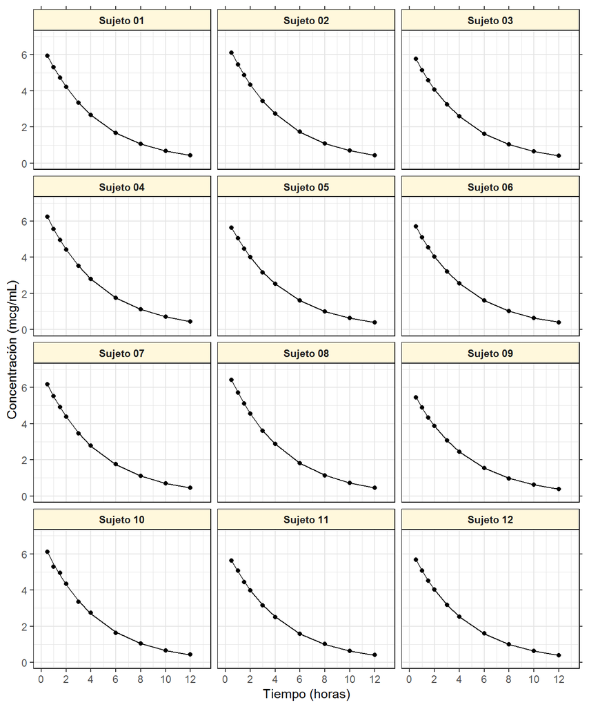

Producto IV - Datos Individuales

Diagnósticos Modelos 1 Compartimento (Producto IV)

| ID | $R^{2}$ | $g_{L}$ | RSE |
| --- | --- | --- | --- |
| Sujeto 01 | 0.999999 | 8 | 0.00261 |
| Sujeto 02 | 0.999999 | 8 | 0.00371 |
| Sujeto 03 | 0.999999 | 8 | 0.00240 |
| Sujeto 04 | 1.000000 | 8 | 0.00164 |
| Sujeto 05 | 0.999996 | 8 | 0.00542 |
| Sujeto 06 | 0.999999 | 8 | 0.00342 |
| Sujeto 07 | 0.999998 | 8 | 0.00433 |
| Sujeto 08 | 0.999999 | 8 | 0.00396 |
| Sujeto 09 | 0.999996 | 8 | 0.00554 |
| Sujeto 10 | 0.999413 | 8 | 0.07530 |
| Sujeto 11 | 0.999897 | 8 | 0.02922 |
| Sujeto 12 | 0.999995 | 8 | 0.00735 |

En la figura 2 y figura 3 se pueden observar todos los datos de administración IV superpuestos en escala de concentraciones normal y logarítmica respectivamente.

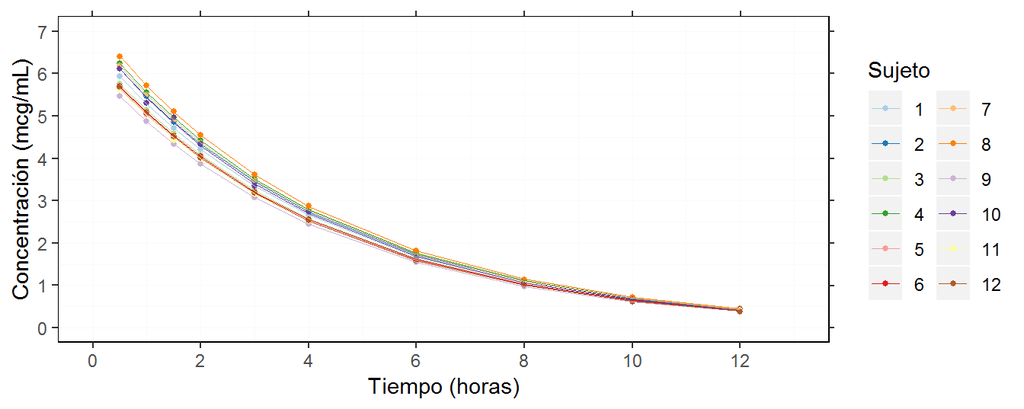

Producto IV - Datos Agrupados

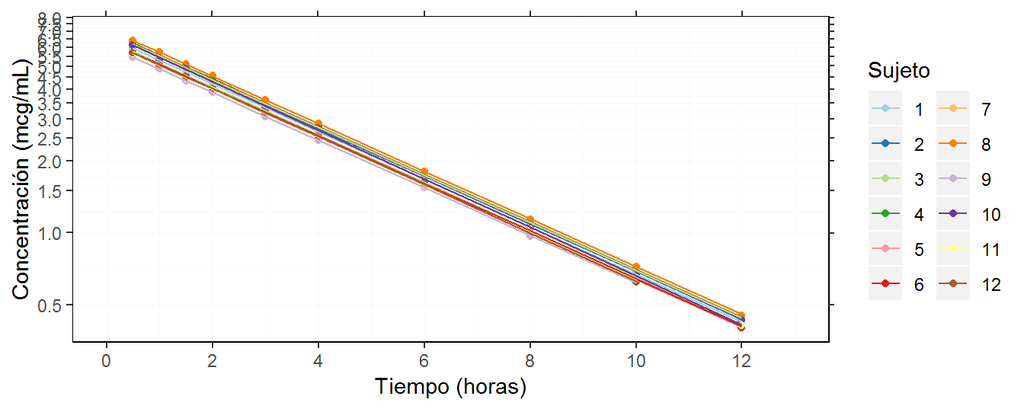

Producto IV - Datos Agrupados (Escala Ln)

## 2.2. Modelamiento Individual Datos Administración Producto A

En el caso de administración peroral, se tiene en cuenta el modelo con administración de un bolo en el compartimento de absorción, y se puede resolver de forma analítica al relacionar $C_{p}$ y tiempo. Al tener en cuenta también el error residual, se tiene el siguiente modelo no lineal:

$$\vec{C_{p}} = \frac{F \cdot D_{0} \cdot k_{a}}{V_{D} \cdot \left(k_{a}-k_{e}\right)}\cdot \left[e^{-k_{e}\cdot\vec{t} }- e^{-k_{a}\cdot\vec{t} } \right] + \vec{\varepsilon} \qquad \vec{\varepsilon}\sim \mathcal{N}(0,\,\sigma^{2})$$

En este caso $F$ es la biodisponibilidad del fármaco para el producto A, mientras $k_{a}$ es la constante de velocidad de absorción. El parámetro $F$ no se puede resolver sin datos de administración IV por lo cual se realiza un modelo reducido para el problema de optimización que tiene en cuenta un volumen de distribución sin el ajuste respectivo por biodisponibilidad, de la siguiente manera:

$$\vec{C_{p}} = \frac{D_{0} \cdot k_{a}}{V^{*} \cdot \left(k_{a}-k_{e}\right)}\cdot \left[e^{-k_{e}\cdot\vec{t} }- e^{-k_{a}\cdot\vec{t} } \right] + \vec{\varepsilon} \qquad \vec{\varepsilon}\sim \mathcal{N}(0,\,\sigma^{2})$$

En este modelo se pueden obtener parámetros farmacocinéticos secundarios como $CL_{T}$ y $t_{1/2}$ de la forma definida previamente. Se hace un resumen de los diferentes parámetros farmacocinéticos obtenidos para el producto A en el cuadro 3, recordando que el volumen de distribución no se ha ajustado a la biodisponibilidad.

Resultados Parámetros Farmacocinéticos (Producto A)

| ID | Dosis | $k_{a}$ | $k_{e}$ | $V^{*}$ | $CL_{T}$ | $t_{1/2}$ |
| --- | --- | --- | --- | --- | --- | --- |
| Sujeto 01 | 700 | 1.504 | 0.23 | 26.279 | 4.788 | 3.017 |
| Sujeto 02 | 700 | 1.504 | 0.23 | 25.513 | 4.650 | 3.017 |
| Sujeto 03 | 700 | 1.503 | 0.23 | 27.090 | 4.933 | 3.017 |
| Sujeto 04 | 700 | 1.503 | 0.23 | 27.653 | 4.564 | 3.015 |
| Sujeto 05 | 700 | 1.504 | 0.23 | 25.025 | 5.034 | 3.017 |
| Sujeto 06 | 700 | 1.505 | 0.23 | 24.336 | 4.992 | 3.017 |
| Sujeto 07 | 700 | 1.503 | 0.23 | 28.559 | 4.599 | 3.017 |
| Sujeto 08 | 700 | 1.504 | 0.23 | 27.370 | 4.440 | 3.016 |
| Sujeto 09 | 700 | 1.504 | 0.23 | 25.272 | 5.199 | 3.018 |
| Sujeto 10 | 700 | 1.501 | 0.23 | 25.510 | 4.732 | 3.008 |
| Sujeto 11 | 700 | 1.501 | 0.23 | 25.023 | 5.041 | 3.009 |
| Sujeto 12 | 700 | 1.500 | 0.23 | 25.505 | 5.052 | 3.007 |

Para modelos con administración peroral, también se pueden obtener parámetros biofarmacéuticos como biodisponibilidad absoluta ($F$), concentración plasmática máxima ($C_{P, max}$) y tiempo de $C_{P, max}$ ($T_{max}$). Estos parámetros se definen por las siguientes fórmulas:

$$F = \frac{\left [ \textrm{AUC}_{\textrm{PO}}\right ]}{\left [ \textrm{AUC}_{\textrm{IV}}\right ]} \times \frac{\left [D_{0}(\textrm{IV})\right ]}{\left [D_{0}(\textrm{PO})\right ]}$$
$$t_{max} = \frac{\ln{k_{a}}-\ln{k_{e}}}{k_{a}-k_{e}}$$

La concentración plasmática máxima se obtiene al reemplazar en la ecuación analítica el $t_{max}$. La biodisponibilidad se ha calculado con datos de $\textrm{AUC}$ total y truncada. Los resultados en parámetros biofarmacéuticos se muestran en el cuadro 4 para el producto A.

Resultados Parámetros Biofarmacéuticos (Producto A)

| ID | $t_{max}$ | $C_{P,max}$ | AUC$_{0}^{C_{P}^{*}}$ | AUC$_{0}^{\infty}$ | $F_{AUC_{TRUNC}}$ | $F_{AUC}$ |
| --- | --- | --- | --- | --- | --- | --- |
| Sujeto 01 | 1.475 | 18.983 | 107.125 | 115.788 | 0.783 | 0.793 |
| Sujeto 02 | 1.474 | 19.554 | 110.343 | 119.267 | 0.783 | 0.793 |
| Sujeto 03 | 1.475 | 18.414 | 103.922 | 112.324 | 0.783 | 0.793 |
| Sujeto 04 | 1.475 | 18.036 | 101.767 | 109.991 | 0.709 | 0.718 |
| Sujeto 05 | 1.475 | 19.934 | 112.505 | 121.604 | 0.865 | 0.876 |
| Sujeto 06 | 1.474 | 20.502 | 115.680 | 125.039 | 0.881 | 0.893 |
| Sujeto 07 | 1.475 | 17.465 | 98.570 | 106.536 | 0.692 | 0.701 |
| Sujeto 08 | 1.475 | 18.224 | 102.823 | 111.134 | 0.696 | 0.706 |
| Sujeto 09 | 1.474 | 19.743 | 111.428 | 120.442 | 0.885 | 0.896 |
| Sujeto 10 | 1.475 | 19.535 | 110.108 | 118.920 | 0.795 | 0.805 |
| Sujeto 11 | 1.475 | 19.915 | 112.270 | 121.257 | 0.865 | 0.875 |
| Sujeto 12 | 1.475 | 19.536 | 110.088 | 118.895 | 0.846 | 0.860 |

En el cuadro 5 se muestran los parámetros de diagnóstico del modelo, para los datos del producto A, en general se observa muy buen ajuste del modelo, por lo cual no se realiza análisis de residuales y pruebas de suposiciones de regresión.

Diagnósticos Modelos (Producto A)

| ID | $R^{2}$ | $g_{L}$ | RSE |
| --- | --- | --- | --- |
| Sujeto 01 | 0.999997 | 8 | 0.01935 |
| Sujeto 02 | 0.999997 | 8 | 0.02148 |
| Sujeto 03 | 0.999997 | 8 | 0.01971 |
| Sujeto 04 | 0.999997 | 8 | 0.01943 |
| Sujeto 05 | 0.999997 | 8 | 0.02132 |
| Sujeto 06 | 0.999997 | 8 | 0.02136 |
| Sujeto 07 | 0.999997 | 8 | 0.01751 |
| Sujeto 08 | 0.999997 | 8 | 0.01963 |
| Sujeto 09 | 0.999997 | 8 | 0.01921 |
| Sujeto 10 | 0.999996 | 8 | 0.02253 |
| Sujeto 11 | 0.999996 | 8 | 0.02227 |
| Sujeto 12 | 0.999996 | 8 | 0.02317 |

En la figura 4 se pueden observar los datos observados y curva con ajuste del modelo discriminado por individuos, etiquetados en `azul celeste`. En la figura 5 y figura 6 se pueden observar todos los datos de administración PO (producto A) superpuestos en escala de concentraciones normal y logarítmica respectivamente.

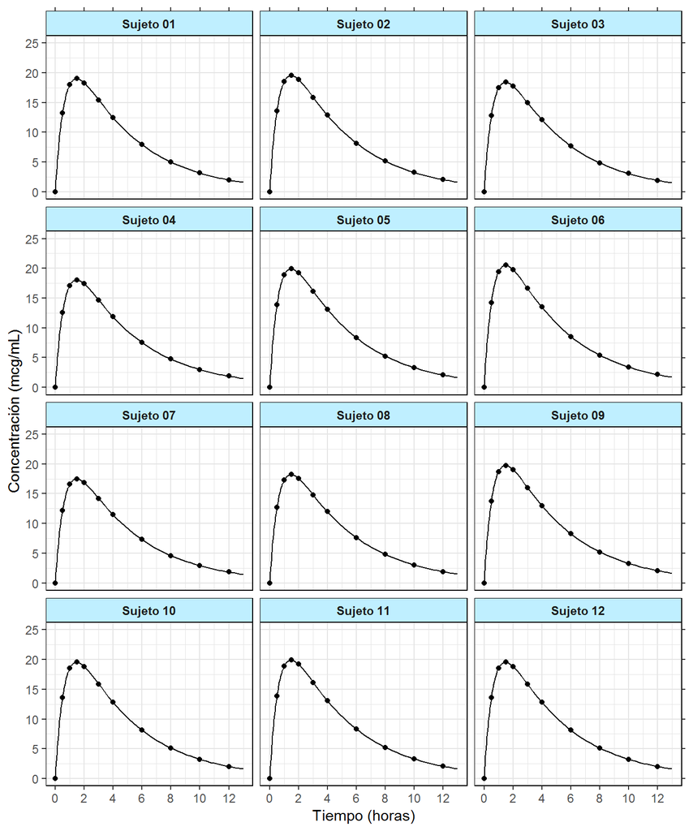

Producto A - Datos Individuales

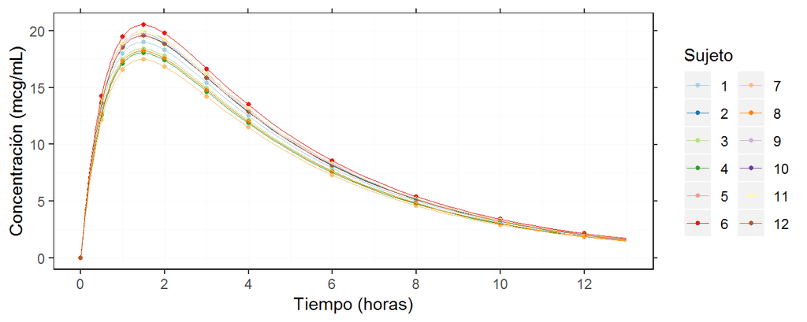

Producto A - Datos Agrupados

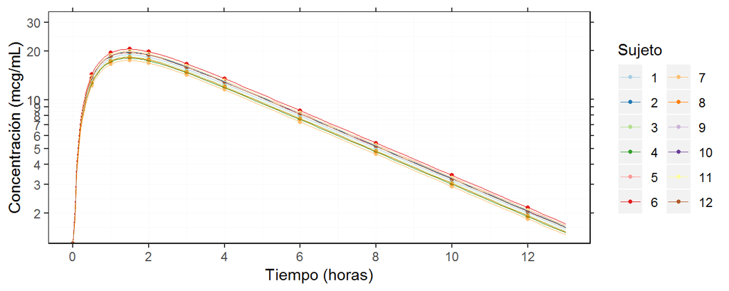

Producto A - Datos Agrupados (Escala Ln)

## 2.3. Modelamiento Individual Datos Administración Producto B

Se hace un resumen de los diferentes parámetros farmacocinéticos obtenidos para el producto B en el cuadro 6, recordando que el volumen de distribución no se ha ajustado a la biodisponibilidad.

Resultados Parámetros Farmacocinéticos (Producto B)

| ID | Dosis | $k_{a}$ | $k_{e}$ | $V^{*}$ | $CL_{T}$ | $t_{1/2}$ |
| --- | --- | --- | --- | --- | --- | --- |
| Sujeto 01 | 700 | 2.797 | 0.23 | 26.286 | 4.760 | 3.018 |
| Sujeto 02 | 700 | 2.797 | 0.23 | 25.276 | 4.624 | 3.018 |
| Sujeto 03 | 700 | 2.796 | 0.23 | 27.379 | 4.905 | 3.019 |
| Sujeto 04 | 700 | 2.797 | 0.23 | 28.574 | 4.537 | 3.018 |
| Sujeto 05 | 700 | 2.796 | 0.23 | 24.334 | 5.005 | 3.017 |
| Sujeto 06 | 700 | 2.798 | 0.23 | 25.032 | 4.964 | 3.018 |
| Sujeto 07 | 700 | 2.797 | 0.23 | 27.661 | 4.573 | 3.017 |
| Sujeto 08 | 700 | 2.796 | 0.23 | 25.519 | 4.414 | 3.018 |
| Sujeto 09 | 700 | 2.797 | 0.23 | 27.099 | 5.171 | 3.018 |
| Sujeto 10 | 700 | 2.793 | 0.23 | 25.281 | 4.705 | 3.011 |
| Sujeto 11 | 700 | 2.792 | 0.23 | 24.340 | 5.011 | 3.011 |
| Sujeto 12 | 700 | 2.791 | 0.23 | 27.386 | 5.023 | 3.011 |

Los resultados en cuanto a parámetros biofarmacéuticos se muestran en el cuadro 7 para el producto B.

Resultados Parámetros Biofarmacéuticos (Producto B)

| ID | $t_{max}$ | $C_{P,max}$ | AUC$_{0}^{C_{P}^{*}}$ | AUC$_{0}^{\infty}$ | $F_{AUC_{TRUNC}}$ | $F_{AUC}$ |
| --- | --- | --- | --- | --- | --- | --- |
| Sujeto 01 | 0.974 | 21.295 | 107.190 | 115.160 | 0.783 | 0.789 |
| Sujeto 02 | 0.974 | 22.146 | 111.457 | 119.731 | 0.791 | 0.797 |
| Sujeto 03 | 0.974 | 20.444 | 102.922 | 110.589 | 0.775 | 0.780 |
| Sujeto 04 | 0.974 | 19.590 | 98.615 | 105.932 | 0.687 | 0.692 |
| Sujeto 05 | 0.974 | 23.001 | 115.755 | 124.332 | 0.889 | 0.895 |
| Sujeto 06 | 0.974 | 22.364 | 112.573 | 120.935 | 0.857 | 0.864 |
| Sujeto 07 | 0.974 | 20.235 | 101.823 | 109.397 | 0.715 | 0.720 |
| Sujeto 08 | 0.974 | 21.934 | 110.418 | 118.606 | 0.748 | 0.753 |
| Sujeto 09 | 0.974 | 20.656 | 103.962 | 111.714 | 0.825 | 0.831 |
| Sujeto 10 | 0.974 | 22.128 | 111.222 | 119.390 | 0.803 | 0.808 |
| Sujeto 11 | 0.974 | 22.982 | 115.520 | 123.991 | 0.890 | 0.894 |
| Sujeto 12 | 0.974 | 20.425 | 102.688 | 110.248 | 0.789 | 0.797 |

En el cuadro 8 se muestran los parámetros de diagnóstico del modelo, para los datos del producto B, en general se observa muy buen ajuste del modelo, por lo cual no se realiza análisis de residuales y pruebas de suposiciones de regresión.

Diagnósticos Modelos (Producto B)

| ID | $R^{2}$ | $g_{L}$ | RSE |
| --- | --- | --- | --- |
| Sujeto 01 | 0.999997 | 8 | 0.02052 |
| Sujeto 02 | 0.999998 | 8 | 0.02076 |
| Sujeto 03 | 0.999997 | 8 | 0.02065 |
| Sujeto 04 | 0.999997 | 8 | 0.01957 |
| Sujeto 05 | 0.999997 | 8 | 0.02299 |
| Sujeto 06 | 0.999998 | 8 | 0.02104 |
| Sujeto 07 | 0.999997 | 8 | 0.01952 |
| Sujeto 08 | 0.999997 | 8 | 0.02206 |
| Sujeto 09 | 0.999998 | 8 | 0.01931 |
| Sujeto 10 | 0.999997 | 8 | 0.02331 |
| Sujeto 11 | 0.999997 | 8 | 0.02575 |
| Sujeto 12 | 0.999997 | 8 | 0.02315 |

En la figura 7 se pueden observar los datos observados y curva con ajuste del modelo discriminado por individuos, etiquetados en `verde`. En la figura 8 y figura 9 se pueden observar todos los datos de administración PO (producto B) superpuestos en escala de concentraciones normal y logarítmica respectivamente.

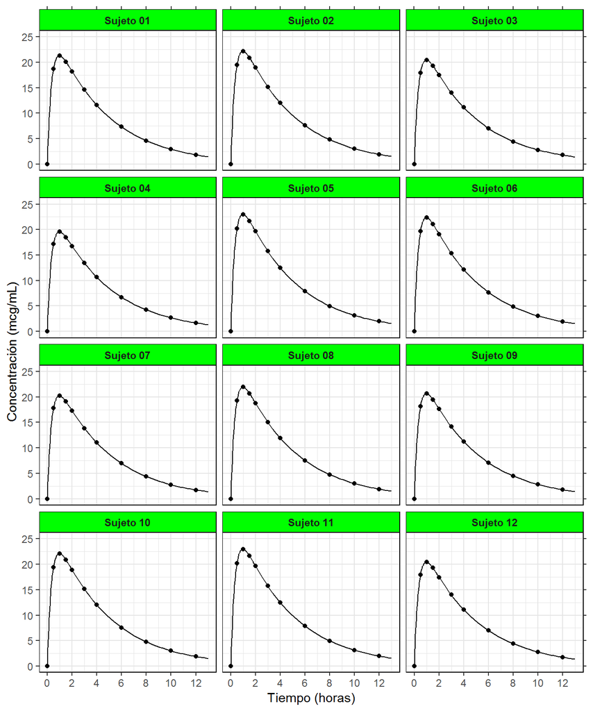

Producto B - Datos Individuales

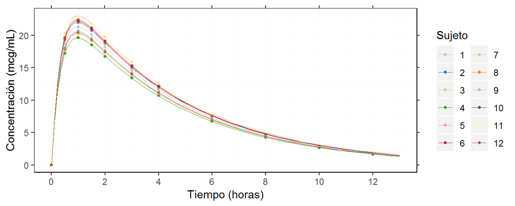

Producto B - Datos Agrupados

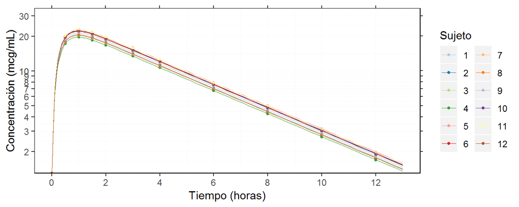

Producto B - Datos Agrupados (Escala Ln)

## 2.4. Comparación de Resultados

Se realiza el cálculo de intervalos de confianza para cada parámetro por forma de administración de acuerdo al método de Cox (estimación de media aritmética en distribuciones log normal) (1). Estos intervalos son definidos por la siguiente fórmula:

$$\bar{Y} + \frac{S^{2}}{2} \pm \left [ t_{1-\frac{\alpha}{2},g_{L}} \cdot \sqrt{\frac{S^{2}}{n} + \frac{S^{4}}{2(n-1)}} \right]$$
En donde, $\bar{Y}$ y $S^{2}$ son la media aritmética y varianza de los valores log-transformados, estos valores se vuelven a transformar por exponenciación. El promedio en este método de estimación sigue la fórmula $\hat{\theta} = e^{\bar{Y}+\frac{S^{2}}{2}}$. En los cuadro 9 y 10 se puede observar una comparación entre productos, teniendo en cuenta el promedo aritmético de los datos originales, e intervalos de confianza (de Cox) de parámetros farmacocinéticos y biofarmacéuticos.

Comparación Parámetros Farmacocinéticos

|  | Producto IV | IC 95% | Producto A | IC 95% | Producto B | IC 95% |
| --- | --- | --- | --- | --- | --- | --- |
| $V_{D}$ | 21.16 | 20.472 - 21.83 | 21.03 | 20.358 - 21.681 | 20.92 | 20.254 - 21.569 |
| $k_{e}$ | 0.23 | 0.23 - 0.231 | 0.23 | 0.23 - 0.23 | 0.23 | 0.23 - 0.23 |
| $CL_{T}$ | 4.88 | 4.719 - 5.029 | 4.84 | 4.68 - 4.985 | 4.81 | 4.653 - 4.956 |
| $t_{1/2}$ | 3.01 | 2.996 - 3.019 | 3.01 | 3.012 - 3.017 | 3.02 | 3.014 - 3.018 |
| $k_{a}$ | - | - | 1.50 | 1.502 - 1.504 | 2.80 | 2.794 - 2.797 |
| $\textrm{AUC}_{\textrm{trunc}}$ | 27.17 | 26.292 - 28.009 | 108.05 | 104.657 - 111.319 | 107.85 | 104.106 - 111.428 |
| $\textrm{AUC}$ | 28.98 | 28.042 - 29.873 | 116.77 | 113.104 - 120.29 | 115.84 | 111.831 - 119.672 |

Comparación Parámetros Biofarmacéuticos

|  | Producto A | IC 95% | Producto B | IC 95% |
| --- | --- | --- | --- | --- |
| $t_{max}$ | 1.475 | 1.47455 - 1.47501 | 0.974 | 0.97368 - 0.97404 |
| $C_{max}$ | 19.153 | 18.5495 - 19.73442 | 21.433 | 20.68773 - 22.14738 |
| $F_{\textrm{trunc}}$ | 0.798 | 0.7508 - 0.84285 | 0.796 | 0.75449 - 0.83513 |
| $F_{\textrm{total}}$ | 0.809 | 0.76074 - 0.85396 | 0.802 | 0.76 - 0.84084 |

# 3. Inferencias Estadísticas para Efectos

## 3.1. Enunciado del Problema

En el presente estudio se tiene un diseño cruzado 2 x 2 estándar que puede ser analizado por medio de pruebas estadísticas basadas en dos muestras (no pareadas). En el enunciado inicial del problema no se identifica el grupo (secuencia) de tratamiento de cada individuo, por lo cual se realiza un muestreo aleatorio sin reemplazo de las siguientes secuencias de tratamiento:

Grupos o Secuencias de Tratamiento

| Secuencia | Periodo 1 | Periodo 2 |
| --- | --- | --- |
| 1 (RC) | Formulación Referencia ($Y_{i11}$) | Formulación Competidor ($Y_{i21}$) |
| 2 (CR) | Formulación Competidor ($Y_{i12}$) | Formulación Referencia ($Y_{i21}$) |

Asignación a Secuencias de Tratamiento

| Sujeto | Secuencia | Sujeto | Secuencia | Sujeto | Secuencia |
| --- | --- | --- | --- | --- | --- |
| 1 | 2 (TR) | 5 | 1 (RT) | 9 | 1 (RT) |
| 2 | 1 (RT) | 6 | 2 (TR) | 10 | 2 (TR) |
| 3 | 2 (TR) | 7 | 2 (TR) | 11 | 1 (RT) |
| 4 | 1 (RT) | 8 | 2 (TR) | 12 | 1 (RT) |

## 3.2. Introducción al modelo general

### 3.2.1. Modelo General

> Los métodos y modelos estadísticos de análisis, descritos en el presente documento son tomados de Chow Shein y colaboradores (2) capítulos 1, 3, 4, y 6.

El modelo general que describe al diseño cruzado 2x2, para el $i \textrm{(sujeto)} = 1,2,\cdots,n_{k}$, $j \textrm{(periodo),} k\textrm{(secuencia) = 1,2}$ es el siguiente:
$$Y_{ijk} = \mu + S_{ik} + P_{j} + F_{(j,k)}+C_{j-1,k}+e_{ijk}$$

En donde, $Y_{ijk}$ es la observación (que puede ser $\ln{C_{max}}$ o $\ln{\textrm{AUC}}$) definida para el i-ésimo sujeto, en el j-ésimo periodo y k-ésima secuencia, $\mu$ es la media general de las observaciones, $S_{ik}$ es el efecto aleatorio del i-ésimo sujeto en la k-ésima secuencia, $P{j}$ es el efecto fijo del j-ésimo periodo, $F_{j,k}$ es el efecto fijo directo de la formulación en la k-ésima secuencia y j-ésimo periodo, $C{j-1,k}$ es el efecto fijo de efecto de *carry-over* de primer órden de la formulación en la k-ésima secuencia y (j-1)-ésimo periodo, y por último, $e_{ijk}$ es el error aleatorio (intra individual) en el $Y_{ijk}$.

Se deben cumplir varias suposiciones como $\sum_{j}{P_{j}}$, $\sum{F_{j,k}}$, $\sum{C_{0,k}}$, y $\sum{C_{(j-1,k)}}$ son todos iguales a cero, $S_{i,k}$ se encuentra $i.i.d.$ con media 0 y varianza $\sigma^{2}_{S}$, mientras los $e_{ijk}$ tienen media 0 y varianza $\sigma_{t}^{2}$. El modelo tiene en cuenta variabilidad inter- e intra-individual. En adición, se debe cumplir que:

$$F_{j,k} = \left\{\begin{matrix} F_{R} \textrm{ si } k=j \\ F_{T} \textrm{ si } k \neq j \end{matrix}\right.$$
Por la misma definición de las secuencias si se considera el periodo 1 y secuencia 1 se tiene el efecto de la formulación de referencia. En adición, se considera el efecto de *carry-over*:

$$C_{j-1,k} = \left\{\begin{matrix} C_{R} \textrm{ si } k = 1, j =2 \\ C_{T} \textrm{ si } k = 2, j =2 \end{matrix}\right.$$
Este efecto es debido a la administración de una dosis anterior en el primer periodo para el segundo, y se puede dar cuando no hay un buen periodo de lavado. La significancia de los diferentes efectos puede ser estimada por medio de diferentes ecuaciones. Debido a que se realiza una transformación logarítmica debe tenerse en cuenta que para los parámetros originales el modelo es multiplicativo:
$$X_{ijk} = e^{Y_{ijk}} = \tilde{\mu}\tilde{S}_{ik}\tilde{P}_{j}\tilde{F}_{(j,k)}\tilde{C}_{j-1,k}\tilde{e}_{ijk}$$

### 3.2.2. Efecto de *Carry-Over*

Su estimador $\hat{C}$ se calcula teniendo en cuenta los totales por sujeto para cada secuencia:
$$\hat{C} = \bar{U}_{\bullet2} - \bar{U}_{\bullet1}$$
Estos totales se calculan de la siguiente manera:
$$U_{ij} = Y_{i1k}+Y_{i2k}$$
En este caso se suma las observaciones de cada sujeto en cada secuencia, estas se promedian en la secuencia k para obtener $\bar{U}_{\bullet k}$. La varianza estimada $\hat{V}(\hat{C})$, se describe por las siguientes ecuaciones:
$$\hat{V}(\hat{C}) = \sigma_{u}^{2}\left (\frac{1}{n_{1}}+\frac{1}{n_{2}} \right )$$
$$\hat{\sigma_{u}^{2}} = \frac{1}{n_{1}+n_{2}-2} \sum_{k=1}^{2}\sum_{i=1}^{n_{k}}{(U_{ik}-\bar{U}_{\bullet k})^{2}}$$
Se utiliza una prueba t (no pareada) para conocer la “significancia” de este efecto, es decir, si es diferente de cero. El $T_{\textrm{c}}$ y el intervalo de confianza se calculan por medio de las siguientes ecuaciones:
$$T_{\textrm{c}} = \frac{\hat{C}}{\hat{\sigma_{u}}\cdot\sqrt{\frac{1}{n_{1}}+\frac{1}{n_{2}}}}$$
$$\hat{C} \pm t_{\alpha/2, n_{1}+n_{2}-2} \hat{\sigma_{u}} \sqrt{\frac{1}{n_{1}}+\frac{1}{n_{2}}}$$

Las hipótesis son las siguientes $H_{0}: C=0$ o $(C_{R} = C_{C})$ vs $H_{a}: C \neq 0$ o $(C_{R} \neq C_{C})$. Si se cumple $H_{0}$ se tiene que $T_{\textrm{c}}$ tiene una distribución central t con $g_{L} = n_{1}+n_{2}-2$, por tal, se rechaza la $H_{0}$ si:
$$\left |T_{\textrm{c}} \right | > t_{\alpha/2,n_{1}+n_{2}-2}$$

### 3.2.3. Efecto de *Formulación*

Se deben definir inicialmente las diferencias en el valor observado del periodo 2 al periodo 1 en cada sujeto y en cada secuencia:
$$d_{ik} = \frac{1}{2} \left ( Y_{i2k} -Y_{i1k}\right ),\textrm{ para }i=1,2,...,n_{k}; k = 1,2$$
Se distinguen dos casos, cuando $C_{R}=C_{C}$ (no *carry-over*) y $C_{R} \neq C_{C}$ (hay *carry-over*), en el segundo caso no es posible obtener estimadores no sesgados del efecto de la formulación. En el caso sin carry-over se define al estimador del efecto de la formulación como:

$$\hat{F} = \bar{d}_{\bullet1}-\bar{d}_{\bullet2}$$
$$\hat{F} = \frac{1}{2}\left[\left(\bar{Y}_{\bullet21}-\bar{Y}_{\bullet11}\right)-\left(\bar{Y}_{\bullet22}-\bar{Y}_{\bullet12}\right)\right]$$
$$\hat{F} = \bar{Y}_{C}-\bar{Y}_{R}$$
De manera alternativa, se puede obtener el estimador por medio de la siguiente fórmula:
$$\hat{F}^{*} = \frac{1}{n_{1}+n_{2}} \cdot\left(\left\{\sum_{i=1}^{n_{1}}{Y_{i21}}+\sum_{i=1}^{n_{2}}{Y_{i12}}\right\}-\left\{\sum_{i=1}^{n_{1}}{Y_{i11}}+\sum_{i=1}^{n_{2}}{Y_{i22}}\right\}\right )$$
La varianza del estimador se puede obtener por medio de las siguientes fórmulas:

$$\hat{V}(\hat{F}) = \sigma_{d}^{2}\left (\frac{1}{n_{1}}+\frac{1}{n_{2}} \right )$$
$$\hat{\sigma_{d}^{2}} = \frac{1}{n_{1}+n_{2}-2} \sum_{k=1}^{2}\sum_{i=1}^{n_{k}}{(d_{ik}-\bar{d}_{\bullet k})^{2}}$$
Se utiliza una prueba t (no pareada) para conocer la “significancia” de este efecto, es decir, si es diferente de cero. El $T_{\textrm{d}}$ y el intervalo de confianza se calculan por medio de las siguientes ecuaciones:
$$T_{\textrm{d}} = \frac{\hat{F}}{\hat{\sigma_{d}}\cdot\sqrt{\frac{1}{n_{1}}+\frac{1}{n_{2}}}}$$
$$\hat{F} \pm t_{\alpha/2, n_{1}+n_{2}-2} \hat{\sigma_{d}} \sqrt{\frac{1}{n_{1}}+\frac{1}{n_{2}}}$$
Las hipótesis son las siguientes $H_{0}: F=0$ o $(F_{R} = F_{C})$ vs $H_{a}: F \neq 0$ o $(F_{R} \neq F_{C})$. Si se cumple $H_{0}$ se tiene que $T_{\textrm{d}}$ tiene una distribución central t con $g_{L} = n_{1}+n_{2}-2$, por tal, se rechaza la $H_{0}$ si:
$$\left |T_{\textrm{d}} \right | > t_{\alpha/2,n_{1}+n_{2}-2}$$

### 3.2.4. Efecto de Formulación (cuando hay *carry-over*)

Se puede obtener un estimador no sesgado de $F$ si sólo se utilizan los datos del primer periodo para cada sujeto, sin embargo, se pierden datos y precisión en la estimación. El estimador y su varianza se pueden calcular por medio de las siguientes expresiones:
$$\hat{F}|C = \bar{Y}_{\bullet12} - \bar{Y}_{\bullet11}$$
$$V(\hat{F}|C) = (\sigma_{S}^{2}+\sigma_{e}^{2})\left (\frac{1}{n_{1}}+\frac{1}{n_{2}}\right)$$
En la práctica, es de importancia extrema tener un periodo de lavado suficiente entre periodos de dosificación para eliminar efectos de administración previa. El estimados no sesgado de la varianza es el siguiente:
$$\hat{V}(\hat{F}|C) = (S_{f}^{2})\left (\frac{1}{n_{1}}+\frac{1}{n_{2}}\right)$$
$$S_{f}^{2} = \frac{1}{n_{1}+n_{2}-2} \sum_{k=1}^{2}\sum_{i=1}^{n_{k}}{\left ( Y_{i1k} - \bar{Y}_{\bullet1k}\right )^{2}}$$
Se utiliza una prueba t (no pareada) para conocer la “significancia” de este efecto, es decir, si es diferente de cero. El $T_{\textrm{d}}$ y el intervalo de confianza se calculan por medio de las siguientes ecuaciones:
$$T_{\textrm{d}} = \frac{\hat{F}|C}{S_{f}\cdot\sqrt{\frac{1}{n_{1}}+\frac{1}{n_{2}}}}$$
$$\hat{F}|C \pm t_{\alpha/2, n_{1}+n_{2}-2} S_{f} \sqrt{\frac{1}{n_{1}}+\frac{1}{n_{2}}}$$
Las hipótesis son las siguientes $H_{0}: F=0$ o $(F_{R} = F_{C})$ vs $H_{a}: F \neq 0$ o $(F_{R} \neq F_{C})$. Si se cumple $H_{0}$ se tiene que $T_{\textrm{d}}$ tiene una distribución central t con $g_{L} = n_{1}+n_{2}-2$, por tal, se rechaza la $H_{0}$ si:
$$\left |T_{\textrm{d}} \right | > t_{\alpha/2,n_{1}+n_{2}-2}$$
Esta forma de análisis con *carry-over* tiene menos poder para detectar diferencias de bioequivalencia debido a que puede haber mayor variabilidad inter-individual, en adición hay un sacrificio de la mitad de la información que elimina los beneficios de un diseño cruzado.

### 3.2.5. Efecto del Periodo

En cuanto al efecto del periodo se debe considerar como:
$$O_{ik} = \left\{\begin{matrix} d_{ik} \textrm{ para sujetos en S1}\\ -d_{ik}\textrm{ para sujetos en S2} \end{matrix}\right.$$
$$\bar{O}_{ik} = \left\{\begin{matrix} \bar{d}_{\bullet1} \textrm{ para k = 1}\\ -\bar{d}_{\bullet2}\textrm{ para k = 2} \end{matrix}\right.$$

El estimador del efecto del periodo se calcula mediante la siguiente expresión:

$$\hat{P} = \bar{O}_{\bullet1}-\bar{O}_{\bullet2}$$
Se utiliza una prueba t (no pareada) para conocer la “significancia” de este efecto, es decir, si es diferente de cero. El $T_{\textrm{O}}$ y el intervalo de confianza se calculan por medio de las siguientes ecuaciones:
$$T_{\textrm{O}} = \frac{\hat{P}}{\sigma_{d}^{2}\cdot\sqrt{\frac{1}{n_{1}}+\frac{1}{n_{2}}}}$$
$$\hat{P} \pm t_{\alpha/2, n_{1}+n_{2}-2} \sigma_{d}^{2} \sqrt{\frac{1}{n_{1}}+\frac{1}{n_{2}}}$$
Las hipótesis son las siguientes $H_{0}: P_{1} = P_{2}$ vs $H_{a}: P_{1} \neq P_{2}$. Si se cumple $H_{0}$ se tiene que $T_{\textrm{O}}$ tiene una distribución central t con $g_{L} = n_{1}+n_{2}-2$, por tal, se rechaza la $H_{0}$ si:
$$\left |T_{\textrm{O}} \right | > t_{\alpha/2,n_{1}+n_{2}-2}$$

## 3.3. Resultados de Inferencia de efectos en AUC

Para conocer la influencia de los efectos se tiene que hacer transformación logarítmica de los resultados AUC. Se realizaron los cálculos previamentes expuestos.

### 3.3.1. Carry-Over en AUC

Se tiene que $\bar{U}_{\bullet1}$=9.527, $\bar{U}_{\bullet2}$=9.493, y $\hat{\sigma}_{u}^{2}$=9.15E-03, el valor calculado de t es dado por:

$$T_{c}=\frac{9.493-9.527}{\sqrt{9.15*10^{-3}}\left(\frac{1}{6}+\frac{1}{6}\right)}=-0.6028$$

Debido a que $\left|T_{c}\right|=0.6028<t_{0.025,10}$=2.228, no se rechaza la hipótesis nula y este efecto no tiene significancia (al no ser diferente de cero), el valor p de este test es 0.560. El valor estimado de *carry-over* es $\hat{C}=-0.0333\;(\textrm{IC95}\%-0.1563,0.0898)$, el intervalo de confianza cruza por el valor de cero, lo cual es consistente con el resultado del test t. Por todo esto, se pueden usar los datos de ambos periodos para conocer el efecto de la formulación.

### 3.3.2. Efecto de Formulación en AUC

Se tiene que $\bar{d}_{\bullet1}$=-0.0233, $\bar{d}_{\bullet2}$=-0.0069, y $\hat{\sigma}_{d}^{2}$=1.657E-03. El valor de F es calculado como:
$$\hat{F} = \bar{d}_{\bullet1} - \bar{d}_{\bullet2} = -0.0233 + 0.0069 = -0.0165$$
El cálculo del valor t es dado por:

$$T_{d}=\frac{-0.0165}{\sqrt{1.657*10^{-3}}\left(\frac{1}{6}+\frac{1}{6}\right)}=-0.701$$

Debido a que $\left|T_{d}\right|=0.701<t_{0.025,10}$=2.228, no se rechaza la hipótesis nula y este efecto no tiene significancia (al no ser diferente de cero), el valor p de este test es 0.4994. El intervalo de confianza del efecto de formulación es $\textrm{IC95}\%-0.0688,0.0359$, este cruza el valor de cero, lo que es consistente con el resultado del test t. En adición, existe una forma alternativa de estimar el efecto de formulación bajo la cual $\hat{F}=-0.0082\;(\textrm{IC95}\%-0.0606,0.0441)$, en este caso $T_{d}$=-0.3503. Estos resultados indican que el efecto de la formulación no es significativo en el resultado de AUC.

### 3.3.3. Efecto de Periodo en AUC

Debido a que $\left|T_{o}\right|=1.2845<t_{0.025,10}$=2.228, no se rechaza la hipótesis nula y este efecto no tiene significancia (al no ser diferente de cero), el valor p de este test es 0.2279. El efecto del periodo estimado es $\hat{P}=-0.0302\;(\textrm{IC95}\%-0.0825,0.0222)$, el intervalo de confianza cruza por el valor de cero, lo cual es consistente con el resultado del test t. El efecto del periodo no es significativo en el valor de AUC.

### 3.3.4 Resumen para AUC

Resultados Inferencia AUC

|  | MVUE | IC95% | T | Valor p |
| --- | --- | --- | --- | --- |
| Carry-Over | -0.0333 | (-0.1563,0.0898) | -0.6028 | 5.601e-01 |
| Formulación 1 | -0.0165 | (-0.0688,0.0359) | -0.7008 | 4.994e-01 |
| Formulación 2 | -0.0082 | (-0.0606,0.0441) | -0.3504 | 7.333e-01 |
| Periodo | -0.0302 | (-0.0825,0.0222) | -1.2845 | 2.279e-01 |

## 3.4. Resultados de Inferencia de efectos en $C_{max}$

Para conocer la influencia de los efectos se tiene que hacer transformación logarítmica de los resultados $C_{max}$. Se realizaron los cálculos previamentes expuestos.

### 3.4.1. Carry-Over en $C_{max}$

Se tiene que $\bar{U}_{\bullet1}$=6.032, $\bar{U}_{\bullet2}$=5.998, y $\hat{\sigma}_{u}^{2}$=9.25E-03, el valor calculado de t es dado por:

$$T_{c}=\frac{5.998-6.032}{\sqrt{9.25*10^{-3}}\left(\frac{1}{6}+\frac{1}{6}\right)}=-0.6124$$

Debido a que $\left|T_{c}\right|=0.612<t_{0.025,10}$=2.228, no se rechaza la hipótesis nula y este efecto no tiene significancia (al no ser diferente de cero), el valor p de este test es 0.554. El valor estimado de *carry-over* es $\hat{C}=-0.034\;(\textrm{IC95}\%-0.158,0.090)$, el intervalo de confianza cruza por el valor de cero, lo cual es consistente con el resultado del test t. Por todo esto, se pueden usar los datos de ambos periodos para conocer el efecto de la formulación.

### 3.4.2. Efecto de Formulación en $C_{max}$

$$T_{d}=\frac{0.2245}{\sqrt{1.667*10^{-3}}\left(\frac{1}{6}+\frac{1}{6}\right)}=9.506$$

Debido a que $\left|T_{d}\right|=9.506>t_{0.025,10}$=2.228, se rechaza la hipótesis nula y este efecto tiene significancia, el valor p de este test es 2.524E-6. El intervalo de confianza del efecto de formulación es $\textrm{IC95}\%0.172,0.277$, este intervalo no cruza el cero, lo que es consistente con el resultado del test t.

### 3.4.3. Efecto de Periodo en $C_{max}$

Se tiene que $\bar{O}_{\bullet1}$=0.0972, y $\bar{O}_{\bullet2}$=0.1273, el valor calculado de t es dado por:

$$T_{o}=\frac{0.0972-0.1273}{\sqrt{1.667*10^{-3}}\left(\frac{1}{6}+\frac{1}{6}\right)}=-1.273$$

Debido a que $\left|T_{o}\right|=1.273<t_{0.025,10}$=2.228, no se rechaza la hipótesis nula y este efecto no tiene significancia (al no ser diferente de cero), el valor p de este test es 0.2318. El efecto del periodo estimado es $\hat{P}=-0.0301\;(\textrm{IC95}\%-0.0827,0.0226)$, el intervalo de confianza cruza por el valor de cero, lo cual es consistente con el resultado del test t. El efecto del periodo no es significativo en el valor de $C_{max}$.

### 3.4.4. Resumen para $C_{max}$

Resultados Inferencia $C_{max}$

|  | MVUE | IC95% | T | Valor p |
| --- | --- | --- | --- | --- |
| Carry-Over | -0.0340 | (-0.1577,0.0897) | -0.6124 | 5.539e-01 |
| Formulación 1 | 0.2245 | (0.1718,0.2771) | 9.5059 | 2.524e-06 |
| Formulación 2 | 0.1122 | (0.0596,0.1648) | 4.7530 | 7.767e-04 |
| Periodo | -0.0301 | (-0.0827,0.0226) | -1.2730 | 2.318e-01 |

## 3.5 Resumen para $F_{\textrm{TOTAL}}$

Resultados Inferencia $F_{\textrm{TOTAL}}$

|  | MVUE | IC95% | T | Valor p |
| --- | --- | --- | --- | --- |
| Carry-Over | -0.1056 | (-0.3159,0.1047) | -1.1190 | 2.893e-01 |
| Formulación 1 | -0.0165 | (-0.0688,0.0359) | -0.7008 | 4.994e-01 |
| Formulación 2 | -0.0082 | (-0.0606,0.0441) | -0.3504 | 7.333e-01 |
| Periodo | -0.0302 | (-0.0825,0.0222) | -1.2845 | 2.279e-01 |

# 4. Análisis de Varianza de Medidas Repetidas

## 4.1. Introducción

El análisis de varianza para un diseño cruzado 2x2 para la demostración de bioequivalencia tiene como característica ser un ANOVA de medidas repetidas. Este se realiza de esta manera porque las comparaciones son realizadas de manera pareada.

Este ANOVA tiene en cuenta la variabilidad inter- e intra-individual frente a la variabilidad total observada, de acuerdo a la ecuación del modelo general, se tiene en cuenta que el efecto de *carry-over* no es dependiente del individuo, mientras los efectos de la formulación y periodo son dependientes del individuo.

Se considera la suma de cuadrados debido a los individuos, que se compara frente al total, esta SC se calcula de acuerdo a:

$$\begin{aligned}
\textrm{SS}_{total} &=\sum_{k=1}^{2}\sum_{j=1}^{2}\sum_{i=1}^{n_{k}}{\left(Y_{ijk}-\bar{Y}_{\bullet\bullet\bullet}\right)^2}\\
&=\sum_{k=1}^{2}\sum_{j=1}^{2}\sum_{i=1}^{n_{k}}{\left(Y_{ijk}-\bar{Y}_{i\bullet k}+\bar{Y}_{i\bullet k}-\bar{Y}_{\bullet\bullet\bullet}\right)^{2}}\\
&=\sum_{k=1}^{2}\sum_{j=1}^{2}\sum_{i=1}^{n_{k}}{\left (Y_{ijk}-\bar{Y}_{i\bullet k}\right)^{2}}+2\sum_{k=1}^{2}\sum_{i=1}^{n_{k}}{\left (\bar{Y}_{i\bullet k}-\bar{Y}_{\bullet\bullet\bullet}\right)^{2}}\\
&=\textrm{SS}_{\textrm{intraindiv.}}+\textrm{SS}_{\textrm{interindiv.}}
\end{aligned}$$

En este caso, $\bar{Y}_{\bullet\bullet\bullet}$ es la media total de todas las observaciones, $\bar{Y}_{i\bullet k} = \frac{1}{2} \sum_{j=1}^{2}{Y_{ijk}}$. La variabilidad interindividual tiene como componentes:
$$\textrm{SS}_{\textrm{interindiv.}}= \textrm{SS}_{\textrm{carry}}+\textrm{SS}_{\textrm{inter.}}$$

$$\textrm{SS}_{\textrm{carry}}= \frac{n_{1}n_{2}}{2\left(n_{1}+n_{2}\right)} \left\{\left(\bar{Y}_{\bullet 12}+\bar{Y}_{\bullet 22}\right)-\left(\bar{Y}_{\bullet 12}+\bar{Y}_{\bullet 21}\right)\right\}^{2}$$
$$\textrm{SS}_{\textrm{err-inter}}=\sum_{k=1}^{2}\sum_{i=1}^{n_{k}}{\frac{Y_{i\bullet k}^{2}}{2}}-\sum_{k=1}^{2}{\frac{Y_{\bullet\bullet k}^{2}}{2n_{k}}}$$

El estadístico F para el efecto de *carry-over* se calcula mediante la fórmula:
$$F_{c}=
\frac{\textrm{MS}_{\textrm{carry}}}{\textrm{MS}_{\textrm{err-inter}}} =
\frac{\textrm{SS}_{\textrm{carry}}/\left(n_{1}+n_{2}-1\right)}{\textrm{SS}_{\textrm{err-inter}}/\left(n_{1}+n_{2}\right)}$$
Se rechaza la $H_{0}$ si se cumple que $F_{c} > F(\alpha,1,n_{1}+n_{2}-2)$. La variabilidad intraindividual tiene como componentes:
$$\textrm{SS}_{\textrm{intraindiv.}}= \textrm{SS}_{\textrm{F}}+\textrm{SS}_{\textrm{P}}+\textrm{SS}_{\textrm{err-intra}}$$

$$\textrm{SS}_{\textrm{F}}=
\frac{n_{1}n_{2}}{2\left(n_{1}+n_{2}\right)}
\left\{
\left(\bar{Y}_{\bullet 21}+\bar{Y}_{\bullet 11}\right)-
\left(\bar{Y}_{\bullet 22}+\bar{Y}_{\bullet 12}\right)
\right\}^{2}$$

$$\textrm{SS}_{\textrm{P}}=
\frac{n_{1}n_{2}}{2\left(n_{1}+n_{2}\right)}
\left\{
\left(\bar{Y}_{\bullet 21}+\bar{Y}_{\bullet 11}\right)-
\left(\bar{Y}_{\bullet 12}+\bar{Y}_{\bullet 22}\right)
\right\}^{2}$$

$$\textrm{SS}_{\textrm{err-intra}}=
\sum_{k=1}^{2}\sum_{j=1}^{2}\sum_{i=1}^{n_{k}}{\frac{Y_{ijk}^{2}}{2}}-
\sum_{k=1}^{2}\sum_{i=1}^{n_{k}}{\frac{Y_{i\bullet k}^{2}}{2}}-
\sum_{k=1}^{2}\sum_{j=1}^{2}{\frac{Y_{\bullet jk}^{2}}{n_{k}}}+
\sum_{k=1}^{2}{\frac{Y_{\bullet\bullet k}^{2}}{2n_{k}}}$$
Los estadísticos F para los efectos de formulación y periodo, se calculan mediante las siguientes fórmulas:
$$F_{d}=
\frac{\textrm{MS}_{\textrm{F}}}{\textrm{MS}_{\textrm{err-intra}}} =
\frac{\textrm{SS}_{\textrm{F}}/1}{\textrm{SS}_{\textrm{err-intra}}/(n_{1}+n_{2}-2)}$$

$$F_{p}=
\frac{\textrm{MS}_{\textrm{P}}}{\textrm{MS}_{\textrm{err-intra}}} =
\frac{\textrm{SS}_{\textrm{P}}/1}{\textrm{SS}_{\textrm{err-intra}}/(n_{1}+n_{2}-2)}$$
Se rechaza la $H_{0}$ si se cumple que $F_{d} > F(\alpha,1,n_{1}+n_{2}-2)$ en el caso del efecto de la formulación, o $F_{p} > F(\alpha,1,n_{1}+n_{2}-2)$ en el caso del efecto del periodo. En adición, a las anteriores se puede realizar una hipótesis frente a la significancia de la variabilidad inter-individual frente intra-individual, de la siguiente manera:

$$\begin{aligned}
&H_{0}: \sigma_{S}^{2} = 0 \\
\textrm{ vs } &H_{a}: \sigma_{S}^{2} > 0
\end{aligned}$$
El estadístico F para esta prueba se calcula como:
$$F_{v}=
\frac{\textrm{MS}_{\textrm{err-inter}}}{\textrm{MS}_{\textrm{err-intra}}} =
\frac{\textrm{SS}_{\textrm{err-inter}}/(n_{1}+n_{2}-2)}{\textrm{SS}_{\textrm{err-intra}}/(n_{1}+n_{2}-2)}$$
Se rechaza la $H_{0}$ si se cumple que $F_{d} > F(\alpha,n_{1}+n_{2}-2,n_{1}+n_{2}-2)$, la hipótesis nula indica que no hay variabilidad inter-individual. En este diseño 2x2 simple no se puede realizar inferencias sobre las interacciones entre los factores, puesto que se necesita un mayor órden por $g_{L}$.

## 4.2. Resultados en Parámetros BF

En el cuadro 16, 17, y 18 se pueden observar los resultados de comparaciones entre los parámetros biofarmacéuticos $\textrm{AUC}\mid _{0}^{\infty}$, $C_{max}$, y $F$, respectivamente.

ANOVA de medidas repetidas $\textrm{AUC}$

|  | $g_{L}$ | Suma Cuadrados (SC) | Promedio Cuadrados (PC) | $F_{\textrm{CALC}}$ | $F_{\textrm{TAB}}$ | Valor p |
| --- | --- | --- | --- | --- | --- | --- |
| $\mathbf{\textrm{Interindividual}}$ |  |  |  |  |  |  |
| Carry-Over | 1 | 23.181 | 23.181 | 0.381 | 4.965 | 5.51E-01 |
| Residuales | 10 | 608.332 | 60.833 | 5.436 | 2.978 | 6.58E-03 |
| $\mathbf{\textrm{Intraindividual}}$ |  |  |  |  |  |  |
| Formulación | 1 | 5.198 | 5.198 | 0.465 | 4.965 | 5.11E-01 |
| Periodo | 1 | 16.41 | 16.41 | 1.466 | 4.965 | 2.54E-01 |
| Residuales | 10 | 111.911 | 11.191 | - | - | - |
| Totales | 23 | 765.032 | 33.262 | - | - | - |

ANOVA de medidas repetidas Concentración Máxima ($C_{max}$)

|  | $g_{L}$ | Suma Cuadrados (SC) | Promedio Cuadrados (PC) | $F_{\textrm{CALC}}$ | $F_{\textrm{TAB}}$ | Valor p |
| --- | --- | --- | --- | --- | --- | --- |
| $\mathbf{\textrm{Interindividual}}$ |  |  |  |  |  |  |
| Carry-Over | 1 | 0.665 | 0.665 | 0.351 | 4.965 | 5.67E-01 |
| Residuales | 10 | 18.952 | 1.895 | 5.097 | 2.978 | 8.34E-03 |
| $\mathbf{\textrm{Intraindividual}}$ |  |  |  |  |  |  |
| Formulación | 1 | 31.186 | 31.186 | 83.882 | 4.965 | 3.54E-06 |
| Periodo | 1 | 0.425 | 0.425 | 1.143 | 4.965 | 3.10E-01 |
| Residuales | 10 | 3.718 | 0.372 | - | - | - |
| Totales | 23 | 54.946 | 2.389 | - | - | - |

ANOVA de medidas repetidas Biodisponibilidad ($F$)

|  | $g_{L}$ | Suma Cuadrados (SC) | Promedio Cuadrados (PC) | $F_{\textrm{CALC}}$ | $F_{\textrm{TAB}}$ | Valor p |
| --- | --- | --- | --- | --- | --- | --- |
| $\mathbf{\textrm{Interindividual}}$ |  |  |  |  |  |  |
| Carry-Over | 1 | 0.011 | 0.011 | 1.337 | 4.965 | 2.74E-01 |
| Residuales | 10 | 0.084 | 0.008 | 15.102 | 2.978 | 9.42E-05 |
| $\mathbf{\textrm{Intraindividual}}$ |  |  |  |  |  |  |
| Formulación | 1 | 0 | 0 | 0.58 | 4.965 | 4.64E-01 |
| Periodo | 1 | 0.001 | 0.001 | 1.372 | 4.965 | 2.69E-01 |
| Residuales | 10 | 0.006 | 0.001 | - | - | - |
| Totales | 23 | 0.102 | 0.004 | - | - | - |

En el caso de $\textrm{AUC}\mid _{0}^{\infty}$ no se observa influencia de *carry-over*, formulación, o periodo en el parámetro, pero si existe una variabilidad inter-individual apreciable frente a la intra-individual. Para el caso de $F$ también se observa el mismo comportamiento, y se observa aún mayor variabilidad inter-individual comparativa. En el caso de $C_{max}$, se observa influencia significativa de la formulación, pero no de *carry-over*, o periodo en el parámetro, y existe variabilidad inter-individual apreciable frente a la intra-individual.

# 5. Comparaciones de Biodisponibilidad Promedio

## 5.1. Introducción

Este criterio de $80/125$ reemplaza al anterior de $\pm 20$ que se utilizaba en los 90’ en datos no transformados, y en estos se asumía normalidad y homocesdasticidad en la distribución de los parámetros biofarmacéuticos. Sin embargo, esta suposición se cumple muy rara vez en estos parámetros, y la transformación logarítmica permite tener un modelo aditivo, con varianzas homogéneas y menos asimetría.

### 5.1.1. Estimación de Máxima Verosimilitud

Este método asume que los parámetros a considerar se distribuyen de forma log-normal, por lo cual tras transformación se cumplen las suposiciones de normalidad y homocesdasticidad mencionadas en el apartado de inferencias de modelos 2x2. Se tiene por tal una estimación puntual (paramétrica) del intervalo de confianza $(1-2\alpha)$, que es basada en el efecto de la formulación ($F$) previamente descrito. Se tiene que:

$$\hat{\delta}_{ML} = \exp(\hat{F}) = \exp(\bar{Y}_{T}-\bar{Y}_{R})$$

Este estimador es equivalente a las media geométrica de ratios de periodos ($r_{ik}$) obtenidos de las secuencia $k$:

$$\hat{\delta}_{ML} = \sqrt{\left(\frac{\left(\prod_{i = 1}^{n_{1}}{r_{i1}}\right)^{1/n_{1}}}{\left(\prod_{i = 1}^{n_{2}}{r_{i2}}\right )^{1/n_{2}}}\right)}$$
Se tiene que los intervalos de confianza se puede obtener mediante una fórmula paramétrica, debido a que se recomiendan IC 90%, se tiene:
$$(L_{1}, U_{1}) = \hat{F} \pm t_{0.1/2, n_{1}+n_{2}-2}*\sqrt{\left(\hat{\sigma}_{d}^2*\left(\frac{1}{n_{1}}+\frac{1}{n_{2}}\right)\right)}$$
La bioequivalencia promedio se puede declarar si: $\exp{(L_{1})}>80\%$ y $\exp{(L_{2})}<125\%$, de acuerdo a la regla 80-125%. En adición, se pueden calcular estadísticos de sesgo y varianza para este estimador.

$$\hat{\textrm{Sesgo}}(\hat{\delta}_{ML}) = \hat{\delta}_{ML}\left [\exp(m\hat{\sigma}_{d}^{2}/2)-1\right ]$$
$$\hat{\textrm{Varianza}}(\hat{\delta}_{ML}) = \hat{\delta}_{ML}^{2}\exp(m\hat{\sigma}_{d}^{2})\left [\exp(m\hat{\sigma}_{d}^{2})-1\right]$$
$$\hat{\textrm{MSE}}(\hat{\delta}_{ML})=\hat{\textrm{Varianza}}(\hat{\delta}_{ML})+\left(\hat{\textrm{Sesgo}}(\hat{\delta}_{ML})\right)^{2}$$

### 5.1.2. Estimación de Varianza Mínima no Sesgada

El estimador $\hat{\delta}_{ML}$ sobre-estima el valor de $\delta$ cuando la variabilidad intra-sujeto es alta y la muestra es pequeña. Se puede hacer una corrección para mejorar el sesgo de la siguiente manera:

$$\hat{\delta}_{\textrm{MVUE}} = \hat{\delta}_{ML}*\Phi_{f}(-m\textrm{SSD})$$
La función de Neymann-Scott ($\Phi_{f}(-m\textrm{SSD})$) se define de la siguiente manera:
$$\Phi_{f}(-m\textrm{SSD})=\sum_{j=0}^{\infty}{\frac{\Gamma{g_{L}/2}}{\Gamma{\left[(g_{L}/2)+j\right]}*j!}\left [(-m/4)\textrm{SSD}\right]^{j}}$$
En este caso se tiene que $\Gamma{(.)}$ es la función gamma, se tiene que $g_{L}$ son los grados de libertad ($n_{1}+n_{2}-1$, m es un factor que depende del tamaño de la muestra en cada grupo de tratamiento ($m = 1/n_{1} + 1/n_{2}$), SSD es la suma de cuadrados de las diferencias de periodo ($\textrm{SSD} = (n_{1}+n_{2}-2)*\hat{\sigma}_{d}^{2}$), y f es un factor de la serie. Esta serie es de rápida convergencia y se necesitan, a penas, los primeros cinco términos para obtener buena precisión. La varianza de este estimador se puede obtener por:

$$\hat{\textrm{Varianza}}(\hat{\delta}_{\textrm{MVUE}}) = \hat{\textrm{MSE}}(\hat{\delta}_{\textrm{MVUE}})=\hat{\delta}_{ML}\left\{\left[\Phi_{f}(-m\textrm{SSD})\right]^{2}-\Phi_{f}(-4m\textrm{SSD})\right\}$$

Los intervalos de confianza para este estimador no se pueden obtener de manera analítica pero si se pueden obtener por medio de bootstrap no paramétrico. Este estimador es el más recomendado puesto que no presenta sesgo y sólo hay una pequeña pérdida de varianza.

### 5.1.3. Media de Ratios de Sujetos Individuales

Para la determinación del estimador MIR se debe tener en cuenta, la siguiente relación en datos no transformados:

$$\begin{aligned}
r_{ik} = \frac{X_{i2k}}{X_{i1k}} = \left\{\begin{matrix}\frac{\tilde{P}_{2}\tilde{F}_{T}\tilde{e}_{i2k}}{\tilde{P}_{1}\tilde{F}_{R}\tilde{e}_{i1k}} \textrm{ si } k = 1\\\frac{\tilde{P}_{2}\tilde{F}_{R}\tilde{e}_{i2k}}{\tilde{P}_{1}\tilde{F}_{T}\tilde{e}_{i1k}} \textrm{ si } k = 2\end{matrix}\right.
\end{aligned}$$

Se debe tener en cuenta que no haya efectos de *carry-over*, los ratios de sujetos individuales se definen de la siguiente manera:

$$\tilde{r}_{ik} = \left\{\begin{matrix}{r}_{ik}\textrm{ si }k=1\\1/{r}_{ik} \textrm{ si } k=2\end{matrix}\right.$$

Estos estadísticos tienen la capacidad de eliminar el efector de variación interindividual, pero no tienen la capacidad de eliminar el efecto del periodo. El estimador se puede definir de la siguiente manera.

$$\hat{\delta}_{\textrm{MIR}}=\frac{1}{2}\sum_{k=1}^{2}\frac{1}{n_{k}}\sum_{i=1}^{n_{k}}{\tilde{r}_{ik}}$$

Se tienen estimadores de sesgo y varianza descritos por las siguientes fórmulas:
$$\hat{\textrm{Sesgo}}(\hat{\delta}_{MIR}) = \frac{1}{2}\delta\left\{\left[\exp{\frac{\sigma_{T}^2+\sigma_{R}^2}{2}}\right]\left[\exp{(P_{1}-P_{2})}+\exp{(P_{2}-P_{1})}\right]-2
\right\}$$

$$\hat{\textrm{Var}}(\hat{\delta}_{MIR})=\frac{1}{4}V_{\textrm{MIR}}^{*}\left\{\frac{1}{n_{1}}\exp{\left[2(P_{2}-P_{1})\right]}+\frac{1}{n_{2}}\exp{\left[2(P_{1}-P_{2})\right]}\right\}$$

$$V_{\textrm{MIR}}^{*}=\exp{\left[2\left(F_{T}-F_{R}\right)+\left(\sigma_{T}^{2}+\sigma_{R}^{2}\right)\right]}\left\{\exp{\left(\sigma_{T}^{2}+\sigma_{R}^{2}\right)}-1\right\}$$

El sesgo en este caso depende de la variabilidad inter-individual, y del efecto del periodo, y es independiente del tamaño muestral.

### 5.1.4. Ratio de Medias de Formulación

Los RM son definidos mediante las siguientes fórmulas:
$$\bar{X}_{T} = \frac{1}{2}\left(\bar{X}_{\bullet 21}+\bar{X}_{\bullet 12}\right)$$
$$\bar{X}_{R} = \frac{1}{2}\left(\bar{X}_{\bullet 11}+\bar{X}_{\bullet 22}\right)$$

El estimador RM tiene la siguiente fórmula:
$$\hat{\delta}_{RM} = \frac{\bar{X}_{T}}{\bar{X}_{R}}$$

Se puede obtener una medida de sesgo por medio de la siguiente ecuación:
$$\hat{\textrm{Sesgo}}(\hat{\delta}_{RM})=\delta\left\{exp{\left(\frac{\sigma_{T}+\sigma_{D}}{2}\right)}\left[1+\frac{1}{4n}\exp{\sigma_{s}^{2}}\left[\exp{\sigma_{s}^{2}}-1\right]\right]-1\right\}$$

## 5.2. Resultados

## 5.3. Resultados para $\textrm{AUC}\mid_{0}^{\infty}$

En el caso de AUC total se pueden observar los estimadores de diferencias en la tabla 19.

Resumen estimadores de diferencia ($\delta$) de $\textrm{AUC}$

|  | $\delta$ | IC 90% | Sesgo | Varianza (MSE) |
| --- | --- | --- | --- | --- |
| MLE | 0.9918 | (0.9709, 1.0131) | 6.847E-05 | 1.358E-04 |
| MVUE | 0.9917 | (0.9747, 1.0113) | - | 1.358E-04 |
| MIR | 0.9926 | (0.9744, 1.0104) | 9.351E-04 | 2.936E-02 |
| RM | 0.9920 | (0.9578, 1.0264) | 2.576E-04 | - |

Se observa que la diferencia se encuentra entre los límites de 80 a 125% del valor de AUC para el producto de referencia (por tal hay equivalencia en AUC). Los mejores estimadores de acuerdo a su varianza estimada son MLE y MVUE, frente a MIR. La eficiencia de MVUE comparada a MLE es 100.034%.

## 5.4. Resultados para $C_{max}$

En el caso de Cmax se pueden observar los estimadores de diferencias en la tabla 20.

Resumen estimadores de diferencia ($\delta$) de $C_{max}$

|  | $\delta$ | IC 90% | Sesgo | Varianza (MSE) |
| --- | --- | --- | --- | --- |
| MLE | 1.1188 | (1.0951, 1.143) | 7.797E-05 | 1.745E-04 |
| MVUE | 1.1187 | (1.1006, 1.1404) | - | 1.744E-04 |
| MIR | 1.1197 | (1.1009, 1.1397) | 1.062E-03 | 3.736E-02 |
| RM | 1.1190 | (1.0824, 1.1564) | 2.960E-04 | - |

Se tiene que la diferencia tiene sentido positivo, es decir Cmax es mayor en el producto competidor frente al innovador. Sin embargo, el límite superior en el peor de los casos (RM) es 115.6%, lo cual sigue dentro del límite (hay equivalencia en este parámetro Cmax). Los mejores estimadores en este caso son MLE y MVUE, siendo MVUE un poco mejor (eficiencia 100.04%).

## 5.5. Resultados para Biodisponibilidad

Resumen estimadores de diferencia ($\delta$) de $\textrm{F}$

|  | $\delta$ | IC 90% | Sesgo | Varianza (MSE) |
| --- | --- | --- | --- | --- |
| MLE | 0.9918 | (0.9709, 1.0131) | 6.847E-05 | 1.358E-04 |
| MVUE | 0.9917 | (0.9747, 1.008) | - | 1.358E-04 |
| MIR | 0.9926 | (0.9748, 1.012) | 9.351E-04 | 2.936E-02 |
| RM | 0.9910 | (0.9305, 1.0471) | -9.189E-04 | - |

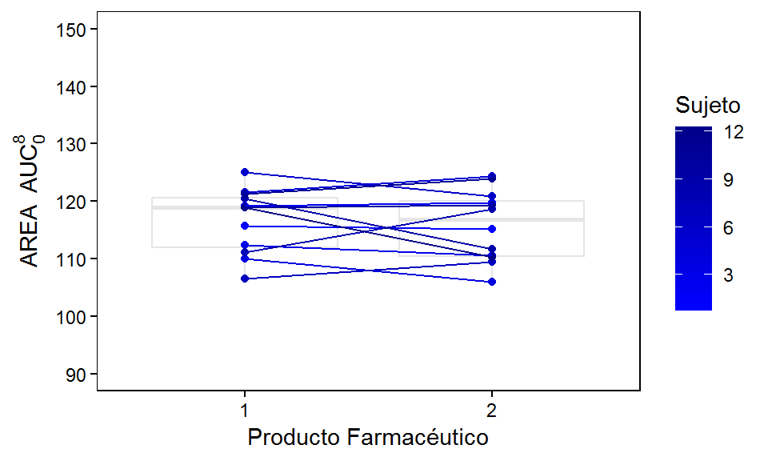

Comparación AUC total

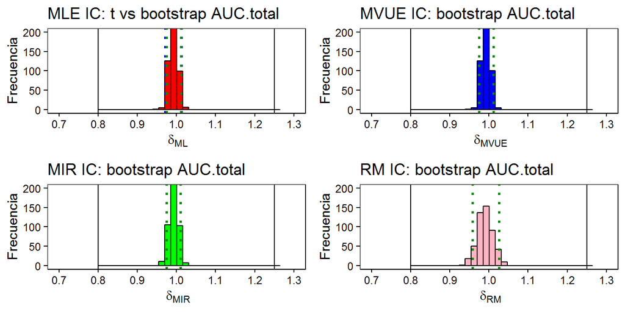

Estimación Diferencias AUC total

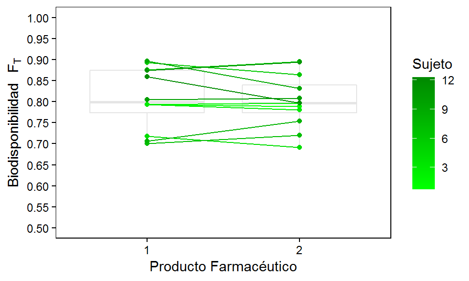

Comparación Biodisponibilidad (F)

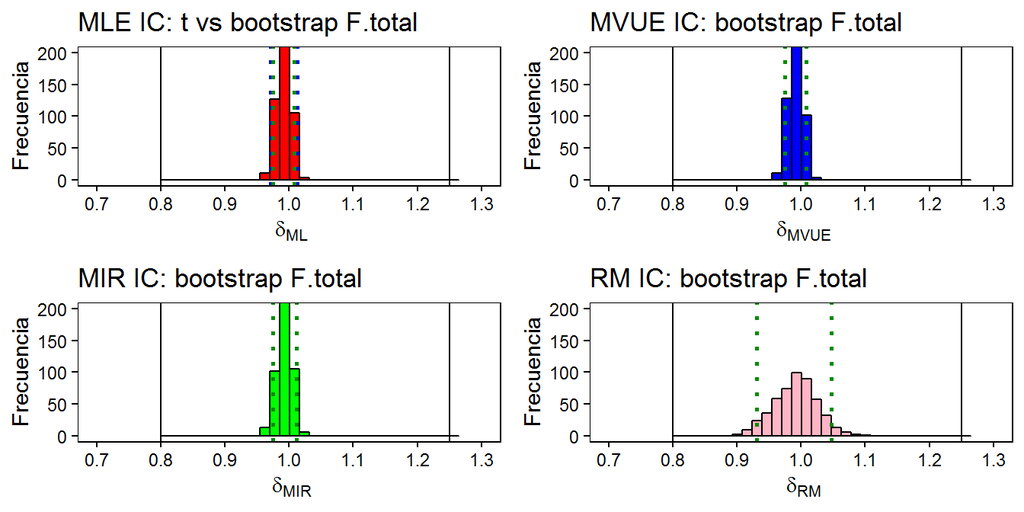

Estimación Diferencias F

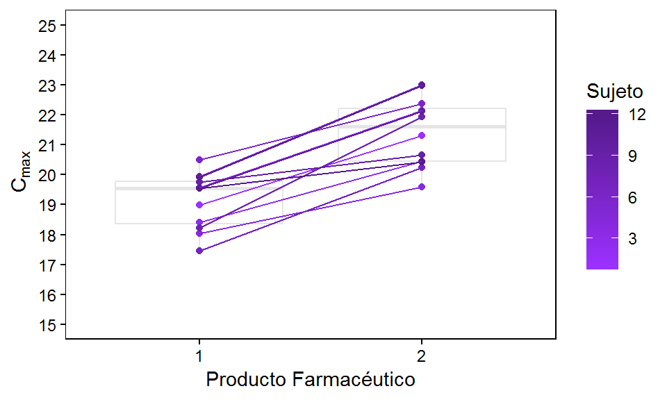

Comparación Cmax

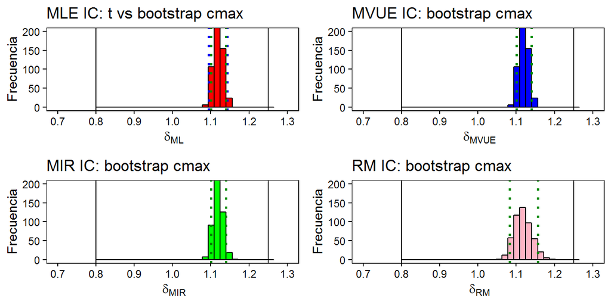

Estimación Diferencias C.max

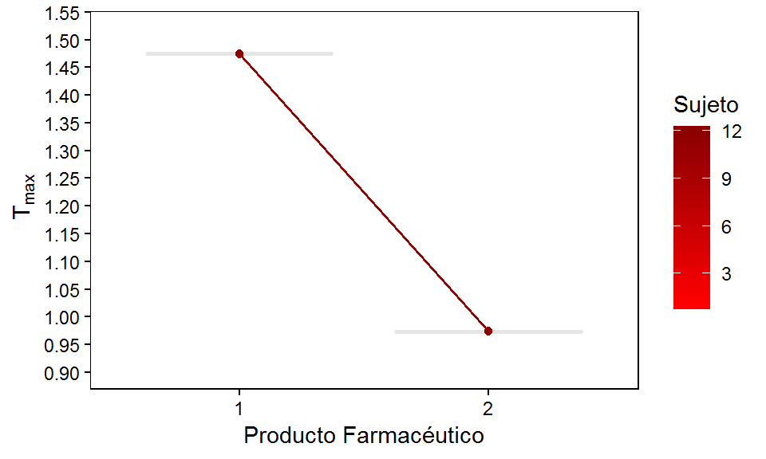

Comparación Tmax

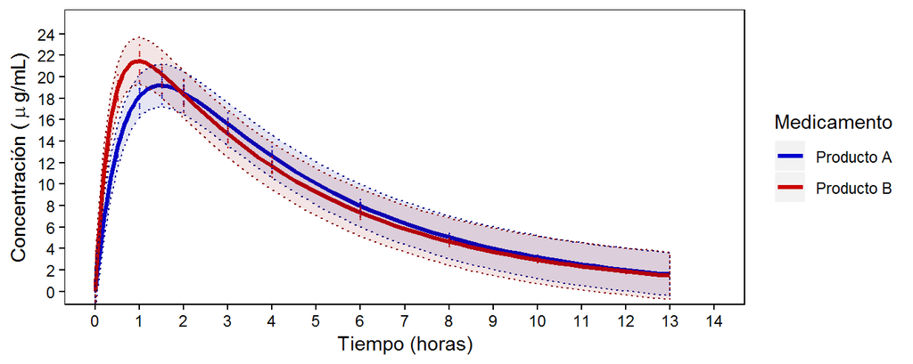

Perfil Promedio de Productos con IC

## 5.6. Resultados en Pruebas no Parámetricas

Se encuentra en principio que el valor para el parámetro en el producto competidor es menor, frente a la referencia. El test de Wilcoxon muestra un valor de estadístico V = 78, mientras el valor tabulado para ese nivel de significancia es 61, el valor p en este caso es 4.88E-04. Por lo cual, se rechaza la hipótesis nula de que la diferencia es igual a cero en este parámetro. Se tiene que la diferencia es significativa para un $\alpha/2 = 0.05$.

No se pueden conocer los valores de todos los efectos tal como en el tratamiento de ANOVA para medidas repetidas, ya que su equivalente es el test de Friedmann sólo permite analizar un factor a la vez. Por lo cual, se sabe que existe la diferencia pero no se conoce si es mayor a los umbrales exigidos por agencias regulatorias.

# 6. Conclusión

Se ha determinado que existen diferencias significativas en el caso $C_{max}$ pero estas no sobrepasan el límite de aseguramiento impuesto por la regla 80/125. En los parámetros de área bajo la curva total ($\textrm{AUC}\mid_{0}^{\infty}$) y biodisponibilidad absoluta ($F$) no se determinaron diferencias significativas debidas a la formulación.

Pueden haber problemas por el efecto en la variación en seguridad y eficacia, y esto depende del fármaco exclusivamente. Se debería evaluar cual es el efecto de un aumento en la $C_{max}$ sobre todo en la seguridad del medicamento. Pese a que esta formulación se puede utilizar de manera intercambiable con el producto de referencia, y se tiene que existe *“prescribability”* puesto que el clínico tiene la libertad de elegir cualquiera de los dos productos en pacientes nuevos ya que se espera el mismo efecto (2).

Sin embargo, no se puede asegurar la *“switchability”* que es la capacidad de cambiar el producto una vez prescrito de manera libre, es decir, en pacientes antiguos a los cuales se ha llevado el fármaco a niveles seguros a través de titulación de la dosis. En este caso, debería realizarse un estudio de ‘bioequivalencia individual’ para demostrarlo. De manera similar, la intercambiabilidad entre diferentes genéricos, ya que se tiene equivalencia con el innovador pero no con otros productos competidores en cuyo caso podrían pasarse los límites impuestos por la regla 80/125.

En conclusión, se puede declarar `bioequivalencia promedio` dado que los parámetros $C_{max}$ y $\textrm{AUC}\mid_{0}^{\infty}$ son equivalentes entre producto de referencia y competidor.

# 7. Bibliografía

1. Olsson U. Confidence intervals for the mean of a log-normal distribution. J Stat Educ. 2005;13(1).

2. Chow S-C, Liu J-P. Design and Analysis of Bioavailability and Bioequivalence Studies. 3rd ed. New York: Taylor & Francis Group, LLC; 2009.

3. World Health Organization. Annex 7. Multisource (generic) pharmaceutical products: guidelines on registration requirements to establish interchangeability. 2006. pp. 131–84.

4. Ministerio de Salud y Protección Social. Anexo Técnico 1. Guía de Biodisponibilidad (BD) y Bioequivalencia (BE) de Productos Farmacéuticos: Por la cual se establece la guía de Biodisponibilidad (BD) y Bioequivalencia (BE) y se dictan otras disposiciones. 2016. pp. 1–47.

5. Rani S, Pargal a. Bioequivalence: An overview of statistical concepts. Indian J Pharmacol. 2004;36(4):209–16.